# Practical Machine Learning Project

Alex Lydick

6/5/2020

## 1.0 - Overview

This is a project for the Johns Hopkins Coursera course on Practical Machine learning. A description for the project is quoted below:

> Using devices such as Jawbone Up, Nike FuelBand, and Fitbit it is now possible to collect a large amount of data about personal activity relatively inexpensively. These type of devices are part of the quantified self movement – a group of enthusiasts who take measurements about themselves regularly to improve their health, to find patterns in their behavior, or because they are tech geeks. One thing that people regularly do is quantify how much of a particular activity they do, but they rarely quantify how well they do it. In this project, your goal will be to use data from accelerometers on the belt, forearm, arm, and dumbell of 6 participants. They were asked to perform barbell lifts correctly and incorrectly in 5 different ways.

Using the provided Datasets, this project aims to predict how the particpants performed their excercise. This is a variable in the training dataset known the “classe”. Details on the methodology will be included throughout the report and my model will later be used to make a prediction for 20 different cases via a course quiz.

## 2.0 - Data Processing

```r
# Environment Set-up
library(knitr)
library(caret)
library(rpart)
library(gbm)
library(rpart.plot)
library(rattle)
library(randomForest)
library(corrplot)
set.seed(12345)
# set.wd("./Coursera/Machine_learning")

# Data loading
training <- read.csv("./pml-training.csv",header=T)
testing <- read.csv("./pml-testing.csv",header=T)

# Create partition of the Training set
parTrain  <- createDataPartition(training$classe, p=0.7, list=FALSE)
train_set <- training[parTrain, ]
test_set  <- training[-parTrain, ]
dim(train_set)
```

```
## [1] 13737   160
```

```r
dim(test_set)
```

```
## [1] 5885  160
```

As we can see, we have 19,622 total entries with 160 variables in the Training set. A good deal of these are NA’s. Those and Near Zero Values, will be removed first. All cleaning processes will be mirrored on the testing dataset that will be used for the prediction quiz.

```r
# Remove NA's
train_set <- train_set[, colSums(is.na(train_set)) == 0]
test_set <- test_set[, colSums(is.na(test_set)) == 0]

# Near Zero Variables Removal
NZV <- nearZeroVar(train_set)
train_set <- train_set[, -NZV]
test_set <- test_set[, -NZV]
dim(train_set)
```

```
## [1] 13737    59
```

```r
dim(test_set)
```

```
## [1] 5885   59
```

The first five columns also need to be removed as they only contain identifacation information like user_name, timestamps, etc.

```r
# Remove ID columns
train_set <- train_set[,-(1:5)]
test_set <- test_set[,-(1:5)]
dim(train_set)
```

```
## [1] 13737    54
```

```r
dim(test_set)
```

```
## [1] 5885   54
```

We’re now down to 54 variables–much more managable. We can now move onto Analysis.

## 3.0 - Analysis

The first step of analysis will be looking at a correlation plot.

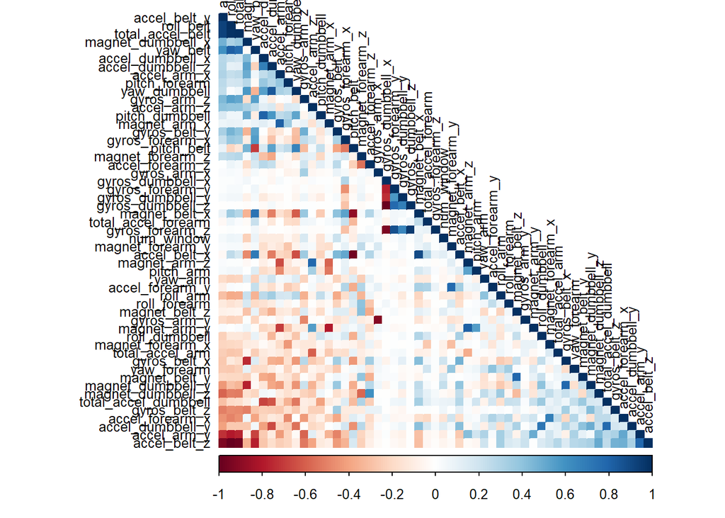

```r
# Plot generation
corrMat <- cor(train_set[, -54])
corrplot(corrMat, order = "FPC", method = "color", type = "lower", tl.cex = 0.8, tl.col = rgb(0,0,0))
```

The variables that are highly correlated are shown in darker colors.

### 3.1 - Model building

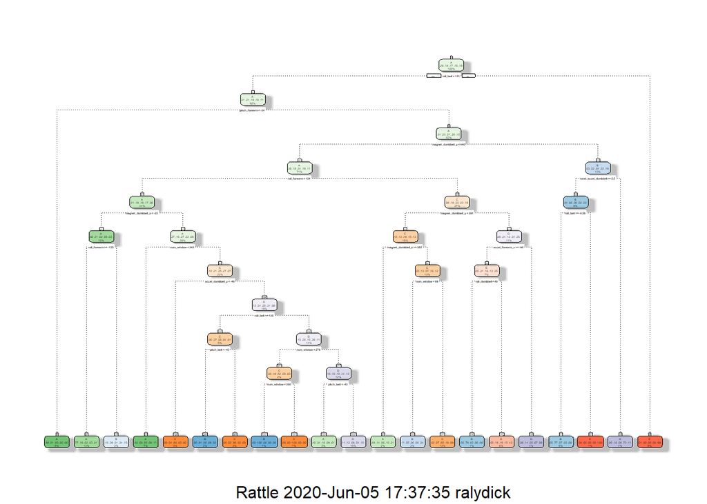

```r
# Model generation
set.seed(12345)
DecTree <- rpart(classe ~., data=train_set,method="class")
fancyRpartPlot(DecTree)
```

```r
# Prediction with Test Set
predTree <- predict(DecTree,newdata=test_set,type="class")
confTree <- confusionMatrix(predTree, test_set$classe)
confTree
```

```
## Confusion Matrix and Statistics
##
##           Reference
## Prediction    A    B    C    D    E
##          A 1502  201   59   66   74
##          B   58  660   37   64  114
##          C    4   66  815  129   72
##          D   90  148   54  648  126
##          E   20   64   61   57  696
##
## Overall Statistics
##
##                Accuracy : 0.7342
##                  95% CI : (0.7228, 0.7455)
##     No Information Rate : 0.2845
##     P-Value [Acc > NIR] : < 2.2e-16
##
##                   Kappa : 0.6625
##
##  Mcnemar's Test P-Value : < 2.2e-16
##
## Statistics by Class:
##
##                      Class: A Class: B Class: C Class: D Class: E
## Sensitivity            0.8973   0.5795   0.7943   0.6722   0.6433
## Specificity            0.9050   0.9425   0.9442   0.9151   0.9579
## Pos Pred Value         0.7897   0.7074   0.7505   0.6079   0.7751
## Neg Pred Value         0.9568   0.9033   0.9560   0.9344   0.9226
## Prevalence             0.2845   0.1935   0.1743   0.1638   0.1839
## Detection Rate         0.2552   0.1121   0.1385   0.1101   0.1183
## Detection Prevalence   0.3232   0.1585   0.1845   0.1811   0.1526
## Balanced Accuracy      0.9011   0.7610   0.8693   0.7936   0.8006
```

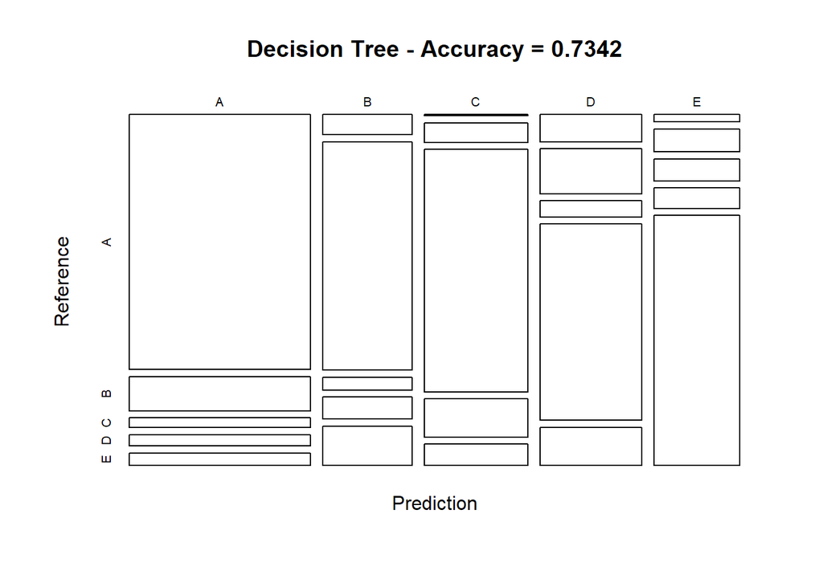

```r
# Plot Results
plot(confTree$table, col = confTree$byClass, main=paste("Decision Tree - Accuracy =", round(confTree$overall["Accuracy"],4)))
```

### 3.3 - Method 2: Random Forest

```r
# model generation
set.seed(12345)
controlForest <- trainControl(method="cv", number=3, verboseIter=FALSE)
modForest <- train(classe ~., data=train_set, method="rf", trControl=controlForest)
modForest$finalModel
```

```
##
## Call:
##  randomForest(x = x, y = y, mtry = param$mtry)
##                Type of random forest: classification
##                      Number of trees: 500
## No. of variables tried at each split: 27
##
##         OOB estimate of  error rate: 0.23%
## Confusion matrix:
##      A    B    C    D    E  class.error
## A 3904    2    0    0    0 0.0005120328
## B    6 2647    4    1    0 0.0041384500
## C    0    5 2391    0    0 0.0020868114
## D    0    0    9 2243    0 0.0039964476
## E    0    0    0    5 2520 0.0019801980
```

```r
# prediction
predictForest <- predict(modForest, newdata = test_set)
confForest <- confusionMatrix(predictForest,test_set$classe)
confForest
```

```
## Confusion Matrix and Statistics
##
##           Reference
## Prediction    A    B    C    D    E
##          A 1674    1    0    0    0
##          B    0 1138    2    0    0
##          C    0    0 1024    2    0
##          D    0    0    0  962    1
##          E    0    0    0    0 1081
##
## Overall Statistics
##
##                Accuracy : 0.999
##                  95% CI : (0.9978, 0.9996)
##     No Information Rate : 0.2845
##     P-Value [Acc > NIR] : < 2.2e-16
##
##                   Kappa : 0.9987
##
##  Mcnemar's Test P-Value : NA
##
## Statistics by Class:
##
##                      Class: A Class: B Class: C Class: D Class: E
## Sensitivity            1.0000   0.9991   0.9981   0.9979   0.9991
## Specificity            0.9998   0.9996   0.9996   0.9998   1.0000
## Pos Pred Value         0.9994   0.9982   0.9981   0.9990   1.0000
## Neg Pred Value         1.0000   0.9998   0.9996   0.9996   0.9998
## Prevalence             0.2845   0.1935   0.1743   0.1638   0.1839
## Detection Rate         0.2845   0.1934   0.1740   0.1635   0.1837
## Detection Prevalence   0.2846   0.1937   0.1743   0.1636   0.1837
## Balanced Accuracy      0.9999   0.9994   0.9988   0.9989   0.9995
```

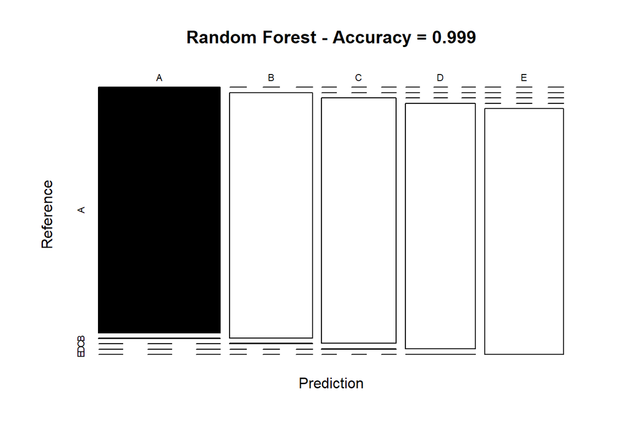

```r
# Confusion Matrix plot
plot(confForest$table, col = confForest$byClass, main=paste("Random Forest - Accuracy =", round(confForest$overall["Accuracy"],4)))
```

### 3.4 - Method 3: Generalized Boosted Model

```r
# Model Generation
set.seed(12345)
controlGBM <- trainControl(method="repeatedcv",number = 5,  repeats=1)
modGBM <- train(classe ~ ., data=train_set,method="gbm",trControl = controlGBM, verbose=FALSE)
modGBM$finalModel
```

```
## A gradient boosted model with multinomial loss function.
## 150 iterations were performed.
## There were 53 predictors of which 53 had non-zero influence.
```

```r
# prediction with test set
predcitGBM <- predict(modGBM, newdata=test_set)
confGBM <- confusionMatrix(predcitGBM, test_set$classe)
confGBM
```

```
## Confusion Matrix and Statistics
##
##           Reference
## Prediction    A    B    C    D    E
##          A 1668   12    0    1    0
##          B    6 1115   12    1    3
##          C    0   12 1012   21    0
##          D    0    0    2  941    6
##          E    0    0    0    0 1073
##
## Overall Statistics
##
##                Accuracy : 0.9871
##                  95% CI : (0.9839, 0.9898)
##     No Information Rate : 0.2845
##     P-Value [Acc > NIR] : < 2.2e-16
##
##                   Kappa : 0.9837
##
##  Mcnemar's Test P-Value : NA
##
## Statistics by Class:
##
##                      Class: A Class: B Class: C Class: D Class: E
## Sensitivity            0.9964   0.9789   0.9864   0.9761   0.9917
## Specificity            0.9969   0.9954   0.9932   0.9984   1.0000
## Pos Pred Value         0.9923   0.9807   0.9684   0.9916   1.0000
## Neg Pred Value         0.9986   0.9949   0.9971   0.9953   0.9981
## Prevalence             0.2845   0.1935   0.1743   0.1638   0.1839
## Detection Rate         0.2834   0.1895   0.1720   0.1599   0.1823
## Detection Prevalence   0.2856   0.1932   0.1776   0.1613   0.1823
## Balanced Accuracy      0.9967   0.9871   0.9898   0.9873   0.9958
```

[figure not shown]

```r
# Confusion Matrix plot
plot(confGBM$table, col = confGBM$byClass, main=paste("Random Forest - Accuracy =", round(confGBM$overall["Accuracy"],4)))
```

## 4.0 - Model Selection

The accuracy of the three prediction methods are listed below:

1. Decision Tree: 0.7342
2. Random Forest: 0.999
3. GBM: 0.9871

As you can see, Random Foresting had the highest reported accuracy. It's out of sample error is be the absolute lowest at 0.001. Compared to GBM's 0.0129 and the Decision Tree's 0.2658. As such, it will be used on the test data set for the upcoming quiz with the following command.

```r
quiz <- predict(modForest, newdata=testing)
quiz
```

```
##  [1] B A B A A E D B A A B C B A E E A B B B
## Levels: A B C D E
```